# Risor ruber - Genetic analyses: relatedness and basic popgen

#### Visualize the filtered genetic-distance results

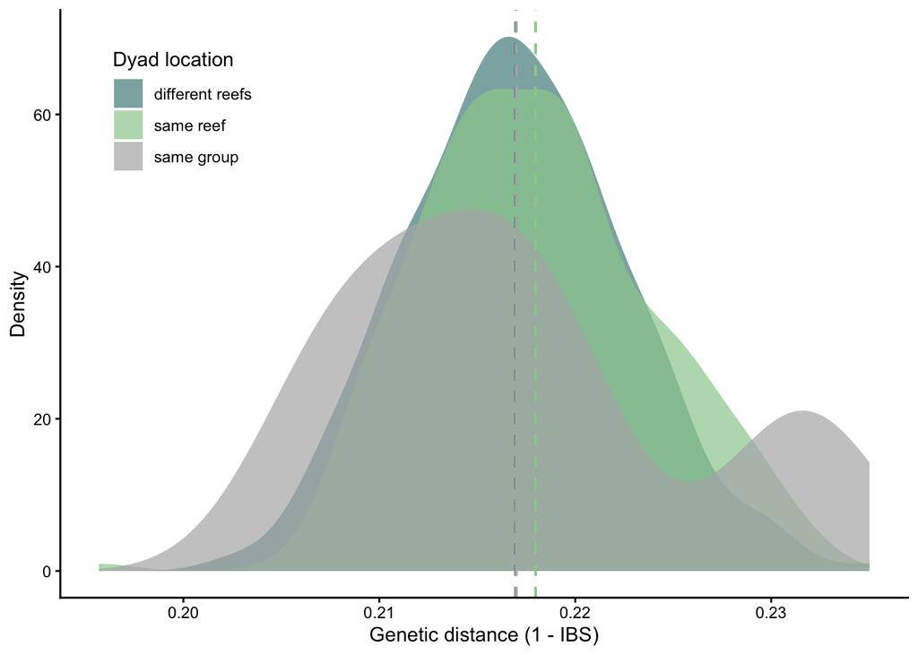

```r
#Figure 2C - Genetic-distance distribution

#arranging df
gd_sponge_main_v2 <- gd_sponge_main %>%
  mutate(
    distance_km = coalesce(distance_km, Distance_m / 1000),
    dist_bin = cut(
      distance_km,
      breaks = c(0, 0.025, 0.075, 0.2, 3.5, Inf),
      labels = c("≤25 m", "25–75 m", "75–200 m", "200–3500 m", ">3500 m"),
      include.lowest = TRUE),
    dyad_loc = case_when(
      as.logical(same_sponge) ~ "same group",
      as.logical(same_reef)   ~ "same reef",
      TRUE                    ~ "different reefs"),
    dyad_loc = factor(dyad_loc,
                      levels = c("different reefs", "same reef", "same group")))

means_df_gd <- gd_sponge_main_v2 %>%
  dplyr::group_by(dyad_loc) %>%
  dplyr::summarise(
    mean_gd = mean(gen_dist, na.rm = TRUE),
    .groups = "drop"
  )

#plotting
cols_gd <- c(
  "same group"       = "grey70",
  "same reef"       = "darkseagreen3",
  "different reefs" = "darkslategray4"
)

ggplot(gd_sponge_main_v2, aes(x = gen_dist, fill = dyad_loc)) +
  geom_density(alpha = 0.7, adjust = 1.0, color = NA) +
  geom_vline(
    data = means_df_gd,
    aes(xintercept = mean_gd, colour = dyad_loc),
    linewidth = 0.7,
    linetype = "dashed",
    show.legend = FALSE
  ) +
  scale_fill_manual(
    values = cols_gd,
    name   = "Dyad location"
  ) +
  scale_colour_manual(
    values = cols_gd
  ) +
  labs(
    x = "Genetic distance (1 - IBS)",
    y = "Density"
  ) +
  theme_classic() +
  theme(
    legend.position      = c(0.05, 0.95),
    legend.justification = c("left", "top"),
    legend.background    = element_rect(fill = "white", colour = NA)
  )
```

```r
ggsave(file.path(output_dir, "Fig_2C.pdf"), width = 5, height = 4, units = "in")
```

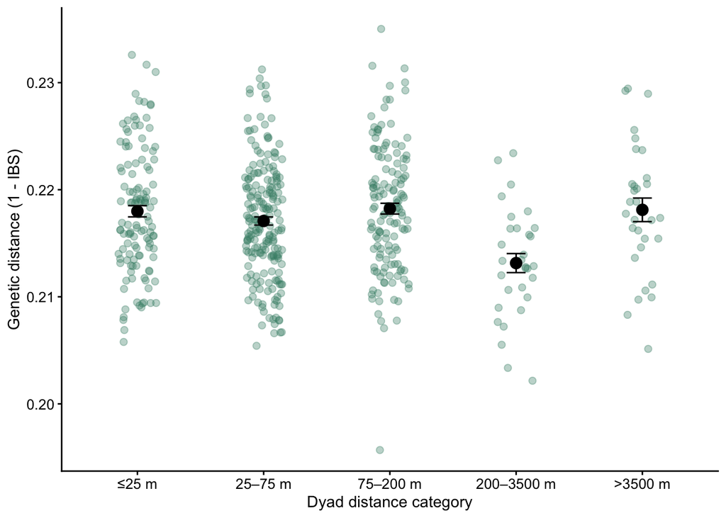

```r
#Figure 2D - Genetic distance by distance class

#arranging df
bin_summ_gd<- gd_sponge_main_v2 %>%
  group_by(dist_bin) %>%
  summarise(
    n_dyads = n(),
    mean_gd = mean(gen_dist, na.rm = TRUE),
    se_gd   = sd(gen_dist, na.rm = TRUE) / sqrt(n()),
    .groups   = "drop"
  )

#plotting
ggplot(gd_sponge_main_v2, aes(x = dist_bin, y = gen_dist)) +
  # raw points
  geom_jitter(
    width  = 0.15,
    size   = 2,
    alpha  = 0.35,
    color  = "aquamarine4"
  ) +
  # bin means
  geom_point(
    data        = bin_summ_gd,
    aes(x = dist_bin, y = mean_gd),
    inherit.aes = FALSE,
    size        = 3,
    color       = "black",
    fill        = "black",
    shape       = 21,
    stroke      = 0.8
  ) +
  # error bars
  geom_errorbar(
    data        = bin_summ_gd,
    aes(x = dist_bin,
        ymin = mean_gd - se_gd,
        ymax = mean_gd + se_gd),
    inherit.aes = FALSE,
    width       = 0.15,
    color       = "black"
  ) +
  labs(
    x = "Dyad distance category",
    y = "Genetic distance (1 - IBS)"
  ) +
  theme_classic() +
  theme(
    axis.text.x      = element_text(size = 10),
    axis.text.y      = element_text(size = 10),
    strip.background = element_blank(),
    legend.position  = "none"
  )
```

```r
ggsave(file.path(output_dir, "Fig_2D.pdf"), width = 5, height = 4, units = "in")
```

## 3. Population-genomic summaries and PCA

The population VCF is converted to `genind` and GDS representations to calculate heterozygosity and inbreeding. Figure S6 presents the PCA of 41 biological individuals: the two technical replicates and the PCA outlier `grunt_159` are excluded, while the remaining documented high-F individuals are retained. Figure S7 provides the corresponding reduced-dataset sensitivity comparison after all documented high-F individuals are removed.

```r
#Converting SNPs to genind object

#Full dataset
vcf_full  <- read.vcfR(vcf_all)
```

```
## Scanning file to determine attributes.
## File attributes:
##   meta lines: 15
##   header_line: 16
##   variant count: 11332
##   column count: 53
## Meta line 15 read in.
## All meta lines processed.
## gt matrix initialized.
## Character matrix gt created.
##   Character matrix gt rows: 11332
##   Character matrix gt cols: 53
##   skip: 0
##   nrows: 11332
##   row_num: 0
## Processed variant 1000Processed variant 2000Processed variant 3000Processed variant 4000Processed variant 5000Processed variant 6000Processed variant 7000Processed variant 8000Processed variant 9000Processed variant 10000Processed variant 11000Processed variant: 11332
## All variants processed
```

```r
genind_full <- vcfR2genind(vcf_full) #FULL DATASET
pop(genind_full) <- factor(rep("pop1", nInd(genind_full))) #same population
hf_full <- genind2hierfstat(genind_full)

#Fitered dataset
# individuals to remove
rm_inds <- c("golden_2",  "golden_3",  "golden_21", "golden_64", "grunt_127", "grunt_159" ,"grunt_181", "long_209",  "long_219" , "golden_52_d", "golden_55_d")

genind_fil <- genind_full[!indNames(genind_full) %in% rm_inds, ]
hf_fil <- genind2hierfstat(genind_fil)
```

```r
basic_stats_all <- basic.stats(hf_full)
basic_stats_all$overall["Fis"] #Overall (global) inbreeding coefficient F_IS 0.363
```

```
##    Fis
## 0.3629
```

```r
basic_stats_fil <- basic.stats(hf_fil) #filtered dataset
basic_stats_fil$overall["Fis"]
```

```
##    Fis
## 0.1246
```

```r
Ho_all <- basic_stats_all$Ho # Observed heterozygosity per locus
He_all <- basic_stats_all$Hs # Expected heterozygosity per locus

Ho_fil <- basic_stats_fil$Ho
He_fil <- basic_stats_fil$Hs

#mean overall
mean(Ho_all, na.rm = TRUE) #observed 0.2115303
```

```
## [1] 0.2115303
```

```r
mean(He_all, na.rm = TRUE) #expected 0.3320372
```

```
## [1] 0.3320372
```

```r
mean(Ho_fil, na.rm = TRUE) #observed 0.2284386
```

```
## [1] 0.2284386
```

```r
mean(He_fil, na.rm = TRUE) #expected 0.2609608
```

```
## [1] 0.2609608
```

```r
head(basic_stats_all$overall)
```

```
##     Ho     Hs     Ht    Dst    Htp   Dstp
## 0.2115 0.3320 0.3320 0.0000    NaN    NaN
```

```r
#Using SNPRelate package
all_ids <- read.gdsn(index.gdsn(genofile_all, "sample.id")) #get all samples id

# Figure S6 uses the biological genotyped dataset after excluding the PCA
# outlier grunt_159. The two technical replicates are also excluded; the
# remaining documented high-F biological individuals are retained.
remove_ids <- c("golden_52_d", "golden_55_d", "grunt_159")

keep_ids <- setdiff(all_ids, remove_ids)

#running PCA
pca_all <- snpgdsPCA(
  genofile_all,
  sample.id = keep_ids,
  autosome.only = TRUE
)
```

```
## Principal Component Analysis (PCA) on genotypes:
## Excluding 0 SNP on non-autosomes
## Excluding 0 SNP (monomorphic: TRUE, MAF: NaN, missing rate: NaN)
##     # of samples: 41
##     # of SNPs: 11,332
##     using 1 thread
##     # of principal components: 32
## PCA:    the sum of all selected genotypes (0,1,2) = 626998
## CPU capabilities:
## Wed Aug 12 14:08:54 2026    (internal increment: 11988)
## [..................................................]  0%, ETC: ---        [==================================================] 100%, completed, 0s
## Wed Aug 12 14:08:54 2026    Begin (eigenvalues and eigenvectors)
## Wed Aug 12 14:08:54 2026    Done.
```

```r
#generate PCA df
pca.df.all<- data.frame(
  id = pca_all$sample.id,
  PC1 = pca_all$eigenvect[,1],
  PC2 = pca_all$eigenvect[,2],
  PC3 = pca_all$eigenvect[,3]
)
#Merge PCA df with metadata
pca.df.all<- merge(pca.df.all, meta_all, by = "id")
head(pca.df.all)
```

```
##           id         PC1         PC2          PC3 id_num   site   lat_dd
## 1 curlew_225  0.07870846 -0.09152525 -0.108773410    225 curlew 16.79016
## 2 golden_114  0.07496759  0.12408317 -0.168020508    114 golden 16.80952
## 3   golden_2 -0.32543487 -0.05339631 -0.002852789      2 golden 16.80947
## 4  golden_21 -0.34477915  0.10934836  0.006752952     21 golden 16.80955
## 5   golden_3 -0.32015159 -0.06057676  0.015888905      3 golden 16.80947
## 6  golden_32  0.07826812  0.20817417  0.170474585     32 golden 16.80958
##      lon_dd depth sponge_id weight    sl    tl batch_n S_width_cm Depth_m
## 1 -88.07636  12.6    CUR_02  0.014  8.51 10.38  batch1   20.91269    12.6
## 2 -88.08556   8.2    GOL_46  0.034 13.05 15.67  batch1   12.03933     8.2
## 3 -88.08546   7.1    GOL_01  0.017  9.18 11.67  batch1   20.84560     7.1
## 4 -88.08570   8.8     GOL_6  0.019 11.48 13.05  batch1   28.50863     8.8
## 5 -88.08546   7.1    GOL_01  0.047 14.19 16.88  batch1   20.84560     7.1
## 6 -88.08563   5.4    GOL_11  0.033 11.17 13.43  batch1   37.26888     5.4
##   Group.size          S_species S_colour Reef AVG.TL_mm R1_TL R10_TL R11_TL
```

[output cut: 27 more lines]

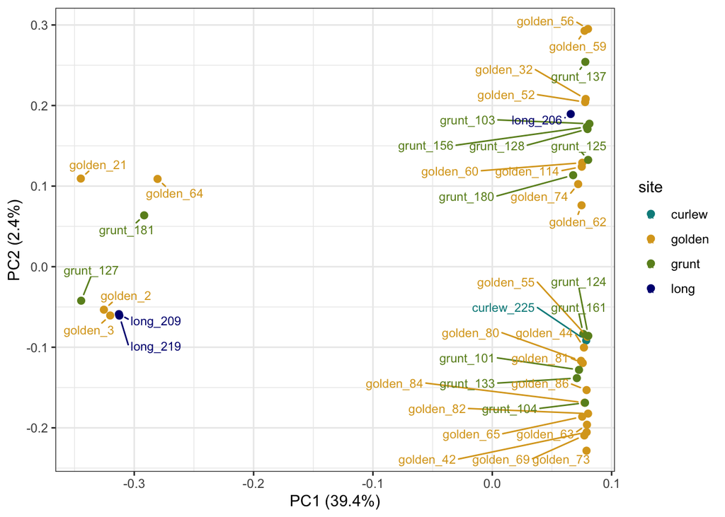

```r
#Plotting PCA
pc.percent <- pca_all$varprop * 100 #obtain percent variance explained

PCA_all<- ggplot(pca.df.all, aes(PC1, PC2, color = site, label = id)) +
  geom_point(size = 2) +
  ggrepel::geom_text_repel(
    size = 3,
    max.overlaps = Inf,
    box.padding  = .4,
    point.padding = .25,
    min.segment.length = 0
  ) +
  labs(
    x = paste0("PC1 (", round(pc.percent[1], 1), "%)"),
    y = paste0("PC2 (", round(pc.percent[2], 1), "%)")
  ) +
 scale_color_manual(values = c("curlew"="#008B8B", "golden" = "#DAA520", "grunt" = "#6B8E23", "long" = "#000080")) +
  theme_bw()

PCA_all
```

```r
ggsave(file.path(output_dir, "Figure_S6.pdf"), width = 8, height = 6, units = "in")
```

PC1 is explaining a lot - which means a strong separation between the two clusters. This is probably driven by the little cluster being really similar to each other - very homozygous.